# HW 3 BMDA

Nat Lim

2026-06-13

In Homework 1 you downloaded and QC’d the 33 FASTQ files for the HIV/TB dataset from SRA. In this assignment you will carry those reads through a complete RNA-seq differential expression analysis.

## RNA-sequencing analysis

##### 1. Align the HIV/TB reads (downloaded in Homework 1) to the human genome reference using your choice of the `Rsubread` or the `STAR` aligners. Confirm whether or not you were able to successfully complete this step (on your honor).

1. Yes
2. No

```r
require("BiocManager")

library(Rsubread)
buildindex("genomefile", "genomefile.fa")

align("genomefile", "myfastqfile.fq",
      output_file="myfastq.bam", nthreads = 4)
```

##### 2. Use the `featureCounts` function in the `Rsubread` package to generate a counts file for this dataset. Upload your feature counts .txt file here.

For the rest of the assignment, please use the feature counts provided by Dr. Johnson in the lecture materials: {https://github.com/wevanjohnson/2026_Spring_BMDA/raw/refs/heads/main/lectures/week6/example_data/features_combined.txt}{features_combined.txt (link)}

##### 3. Generate a `SummarizedExperiment` object for your counts. The `colData` for these data are provided in the `homework2\_metadata.txt` file. What function is used to create a SummarizedExperiment object?

1. **SummarizedExperiment(assays = list(counts = as.matrix(counts)), colData = metadata)**
2. makeSummarizedExp(as.matrix(counts), metadata)
3. seObject(counts, metadata)
4. summarizeData(data = counts, metadata = metadata)
5. buildExperiment(assay = as.matrix(counts), metadata = metadata)

```r
library(SummarizedExperiment)

counts <- read.delim("features_combined.txt", row.names = 1, check.names = FALSE)

metadata <- read.delim("hivtb_SRR_metadata.txt")

rownames(metadata) <- metadata$SampleID
metadata <- metadata[colnames(counts), ]

se <- SummarizedExperiment(assays = list(counts = as.matrix(counts)), colData = metadata
)

se
```

```
## class: SummarizedExperiment
## dim: 25369 33
## metadata(0):
## assays(1): counts
## rownames(25369): DDX11L1 WASH7P ... GOLGA2P3Y GOLGA2P2Y
## rowData names(0):
## colnames(33): R01_1 R01_10 ... R03_32 R03_33
## colData names(3): sample_name SampleID disease_status
```

##### 4. Preprocess these data by removing `TB-HIV-ART` samples (should be two of them), removing any genes with zero expression for all samples, and by generating a log counts per million assay. How may genes were removed with the zero expression filter?

1. 48
2. **2,204**
3. 9,700
4. 17,385

```r
se <- se[, se$disease_status != "TB-HIV-ART"]
dim(se)
```

```
## [1] 25369    31
```

```r
keep <- rowSums(assay(se, "counts")) > 0
n_removed <- sum(!keep)
n_removed
```

```
## [1] 2204
```

```r
se <- se[keep, ]
dim(se)
```

```
## [1] 23165    31
```

```r
library(edgeR)
logcpm <- cpm(assay(se, "counts"), log = TRUE)
assay(se, "logCPM") <- logcpm

se
```

```
## class: SummarizedExperiment
## dim: 23165 31
## metadata(0):
## assays(2): counts logCPM
## rownames(23165): DDX11L1 WASH7P ... RBMY2FP LOC100652931
## rowData names(0):
## colnames(31): R01_1 R01_10 ... R02_30 R02_31
## colData names(3): sample_name SampleID disease_status
```

##### 5. Create a batch corrected assay in your `SummarizedExperiment` using ComBat-Seq. You can use the `ComBat\_Seq` function in the `sva` package, or simply do it in `BatchQC` and then extract the `SummarizedExperiment`. For this example, pretend that `disease\_status` is the batch variable. Note that this will remove the disease status variability, so **don’t** use this assay in the following analyses! This was merely a practice for cases where you have an actual batch variable. What command/syntax would work to apply ComBat-Seq?

1. **ComBat_seq(as.matrix(assay(se, “counts”)), batch = se$disease_status)**
2. ComBat_seq(counts = assay(se), batch = disease_status)
3. BatchFix(se, “counts”, batch = “disease_status”)
4. combatCorrect(se$counts, batch = se$disease_status)
5. ComBat(se, “counts”, batch = “disease_status”)

```r
library(sva)

combat_counts <- ComBat_seq(as.matrix(assay(se, "counts")), batch = se$disease_status)

assay(se, "combat_counts") <- combat_counts

se
```

##### 6. Apply PCA and UMAP to your data and generate dimension reduction plots for the results. Color the TB-HIV to the HIV only samples in different colors. Note that you should be using the log CPM values for this analysis. Please attach your UMAP plot here.

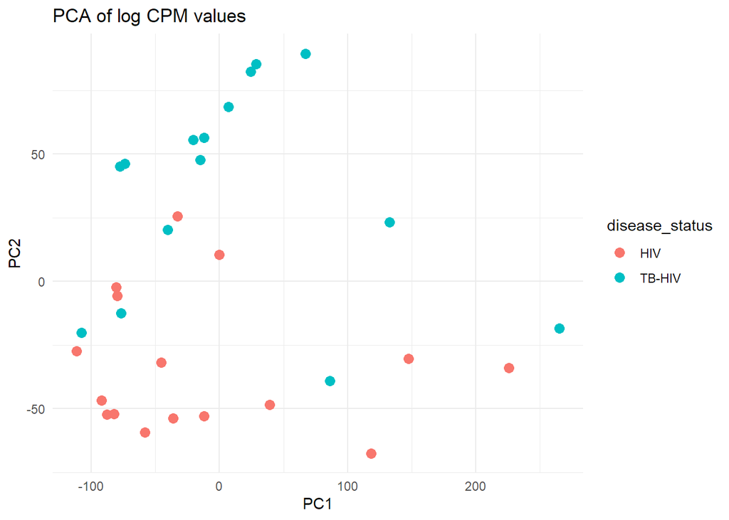

```r
library(umap)

logcpm_mat <- t(assay(se, "logCPM"))

pca <- prcomp(logcpm_mat, scale. = TRUE)
pca_df <- data.frame(
  PC1 = pca$x[,1],
  PC2 = pca$x[,2],
  disease_status = se$disease_status
)

library(ggplot2)
ggplot(pca_df, aes(PC1, PC2, color = disease_status)) +
  geom_point(size = 3) +
  theme_minimal() +
  labs(title = "PCA of log CPM values")
```

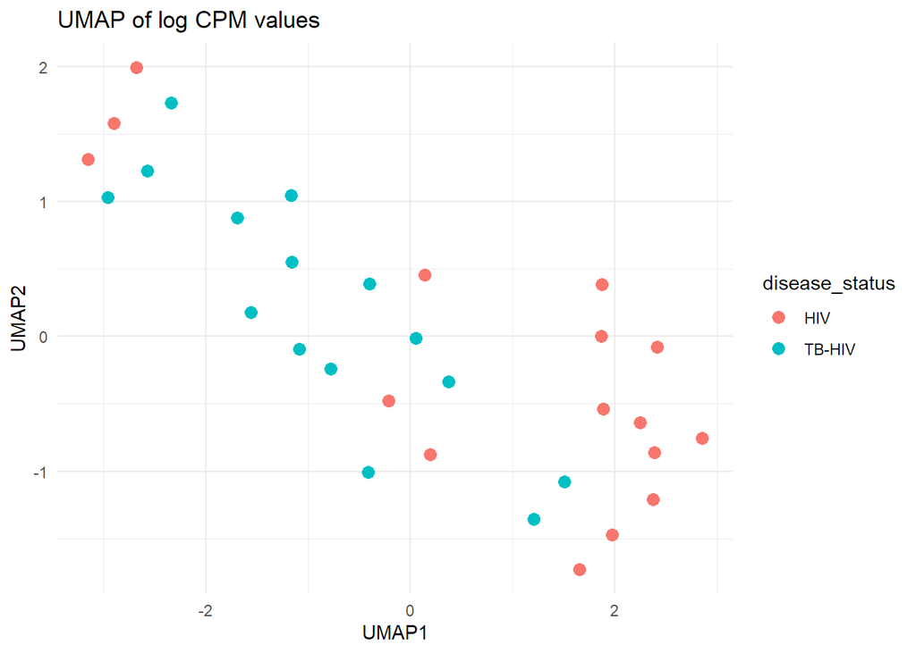

```r
set.seed(42)
umap_res <- umap(logcpm_mat)
umap_df <- data.frame(
  UMAP1 = umap_res$layout[,1],
  UMAP2 = umap_res$layout[,2],
  disease_status = se$disease_status
)

ggplot(umap_df, aes(UMAP1, UMAP2, color = disease_status)) +
  geom_point(size = 3) +
  theme_minimal() +
  labs(title = "UMAP of log CPM values")
```

##### 7. Use `DESeq2` to do a differential expression analysis (on the counts) comparing the TB-HIV to the HIV only samples. What is the twenty second gene on the differentially expressed gene list?

1. IGF2BP3
2. AIM2
3. IL1R2
4. RAB20
5. **FCGR1C**

```r
library(DESeq2)

dds <- DESeqDataSetFromMatrix(
  countData = assay(se, "counts"),
  colData   = colData(se),
  design    = ~ disease_status
)
dds <- DESeq(dds)
res <- results(dds, contrast = c("disease_status", "TB-HIV", "HIV"))

# Order by significance (typically by p-value)
res_ordered <- res[order(res$pvalue), ]
head(as.data.frame(res_ordered), 25)
```

```
##             baseMean log2FoldChange     lfcSE      stat       pvalue
## IGF2BP3    322.60918      2.2793744 0.2534945  8.991811 2.431897e-19
## IL1R2     5421.72921      4.4970417 0.5099882  8.817933 1.165916e-18
## INSL3      221.41779      2.4150674 0.2745705  8.795802 1.420299e-18
## RAB20      619.99640      2.4691348 0.2854034  8.651384 5.087859e-18
## TIFA      1618.99382      2.2245448 0.2584625  8.606839 7.510280e-18
## IL18R1    1520.04146      2.9391929 0.3444572  8.532826 1.428157e-17
## ZAK       1168.60162      2.7506481 0.3285202  8.372843 5.624465e-17
## CYP1B1    2264.69310      3.4285887 0.4103614  8.355047 6.540656e-17
## PDE5A      142.14948      1.6531646 0.1989802  8.308187 9.717513e-17
## SOCS3     1602.56990      2.9600839 0.3605923  8.208948 2.231341e-16
## FAM89A     553.37236      2.8499702 0.3544722  8.040038 8.981046e-16
## FKBP5     3373.91746      2.6493355 0.3297562  8.034224 9.417315e-16
## AP3B2      140.27424      6.0748621 0.7581510  8.012734 1.121865e-15
## VNN1      4702.71546      3.2400724 0.4046598  8.006905 1.176310e-15
## CFH         95.52025      3.3161555 0.4241130  7.819038 5.322865e-15
## FAAH        30.91601     -2.1058122 0.2707140 -7.778735 7.325330e-15
## FCGR1B     835.96622      2.4432772 0.3168971  7.710002 1.258161e-14
## COX15     1080.81562      0.8177984 0.1060918  7.708401 1.274034e-14
## MLK7-AS1   123.60027      2.5453613 0.3314147  7.680291 1.587273e-14
## IRAK3     4000.34948      2.4954537 0.3273382  7.623471 2.469434e-14
## BCL6     27629.37226      2.5803396 0.3389817  7.612031 2.698208e-14
## FCGR1C     422.68044      2.7276400 0.3585950  7.606463 2.816977e-14
## TLK1       896.13810      1.0586705 0.1398255  7.571367 3.693173e-14
## FAM115C    105.45674      1.6871293 0.2230386  7.564293 3.899807e-14
## SAMSN1    1376.64777      2.1051683 0.2790519  7.544003 4.557598e-14
##                  padj
## IGF2BP3  4.322697e-15
## IL1R2    8.415270e-15
## INSL3    8.415270e-15
## RAB20    2.260917e-14
## TIFA     2.669905e-14
## IL18R1   4.230914e-14
## ZAK      1.428212e-13
## CYP1B1   1.453252e-13
## PDE5A    1.919209e-13
## SOCS3    3.966208e-13
## FAM89A   1.394940e-12
## FKBP5    1.394940e-12
## AP3B2    1.493493e-12
## VNN1     1.493493e-12
## CFH      6.307595e-12
## FAAH     8.137983e-12
## FCGR1B   1.258109e-11
## COX15    1.258109e-11
## MLK7-AS1 1.484936e-11
## IRAK3    2.194710e-11
## BCL6     2.275990e-11
## FCGR1C   2.275990e-11
## TLK1     2.854180e-11
## FAM115C  2.888294e-11
## SAMSN1   3.240452e-11
```

```r
# The 22nd gene:
rownames(res_ordered)[22]
```

```
## [1] "FCGR1C"
```

##### 8. Now conduct the same analysis using `limma` on the log CPM values. How do the `DESeq2` results compare to the `limma` results? What is the seventh gene on the differentially expressed gene list?

1. IGF2BP3
2. AIM2
3. **IL1R2**
4. RAB20
5. FCGR1C

```r
library(limma)

logcpm_mat <- assay(se, "logCPM")  # genes as rows, samples as columns

design <- model.matrix(~ disease_status, data = colData(se))

fit <- lmFit(logcpm_mat, design)
fit <- eBayes(fit)

res_limma <- topTable(fit, coef = 2, number = Inf, sort.by = "P")
head(res_limma, 25)
```

```
##              logFC      AveExpr         t      P.Value    adj.P.Val         B
## RAB20     2.151106  4.356875712  8.122894 3.072336e-09 7.117066e-05 10.861574
## PRKAR2B   1.984041  3.506539598  7.237457 3.420877e-08 2.828494e-04  8.678311
## IGF2BP3   2.070735  3.541102728  7.157949 4.265945e-08 2.828494e-04  8.476990
## LOC93432  2.938829 -0.956049304  7.041319 5.904422e-08 2.828494e-04  8.180219
## NOV      -2.720465  0.007183976 -7.029354 6.105104e-08 2.828494e-04  8.149678
## VNN1      3.308877  6.686750401  6.898268 8.813207e-08 3.402632e-04  7.813932
## IL1R2     3.705055  6.016049643  6.769067 1.267618e-07 3.728417e-04  7.481032
## SOCS3     2.783528  5.368634179  6.725569 1.433130e-07 3.728417e-04  7.368526
## FCGR1C    2.708012  3.558764412  6.677385 1.642139e-07 3.728417e-04  7.243659
## CACNA2D3 -2.554606 -0.572631874 -6.664675 1.702239e-07 3.728417e-04  7.210680
## CMTM5     2.489063  3.404847156  6.645928 1.794971e-07 3.728417e-04  7.162004
## ITGB3     2.214878  1.809963528  6.606114 2.009214e-07 3.728417e-04  7.058503
## IL18R1    2.656290  5.344643218  6.591808 2.092356e-07 3.728417e-04  7.021274
## BCL6      2.380581  9.672227025  6.509880 2.640143e-07 4.368493e-04  6.807657
## ZDHHC19   4.394627  3.881058561  6.346064 4.209762e-07 6.308696e-04  6.378553
## GK        1.928722  6.533810193  6.318231 4.557994e-07 6.308696e-04  6.305396
## MYL9      2.478592  3.833094614  6.282726 5.044717e-07 6.308696e-04  6.211978
## GAS2L1    1.491402  2.031060776  6.276377 5.137130e-07 6.308696e-04  6.195261
## CYP1B1    2.983016  5.538704380  6.273848 5.174411e-07 6.308696e-04  6.188602
## INSL3     2.137294  2.922975898  6.216944 6.089421e-07 7.053072e-04  6.038610
## TIFA      1.955061  5.865470452  6.142817 7.530677e-07 8.307053e-04  5.842819
## RTDR1     2.117199 -1.270635662  6.107416 8.335799e-07 8.777217e-04  5.749162
## ANXA3     2.550613  5.904311650  6.043649 1.001124e-06 1.008306e-03  5.580226
## FKBP5     2.246277  6.636365989  5.985204 1.184340e-06 1.133552e-03  5.425137
## MMRN1     2.308777 -0.937030468  5.973942 1.223346e-06 1.133552e-03  5.395226
```

```r
# The 7th gene:
rownames(res_limma)[7]
```

```
## [1] "IL1R2"
```

##### 9. Give a heatmap plot of either the `DESeq2` or the `limma` results (top 50). Add a colorbar for disease status. Upload your plot here.

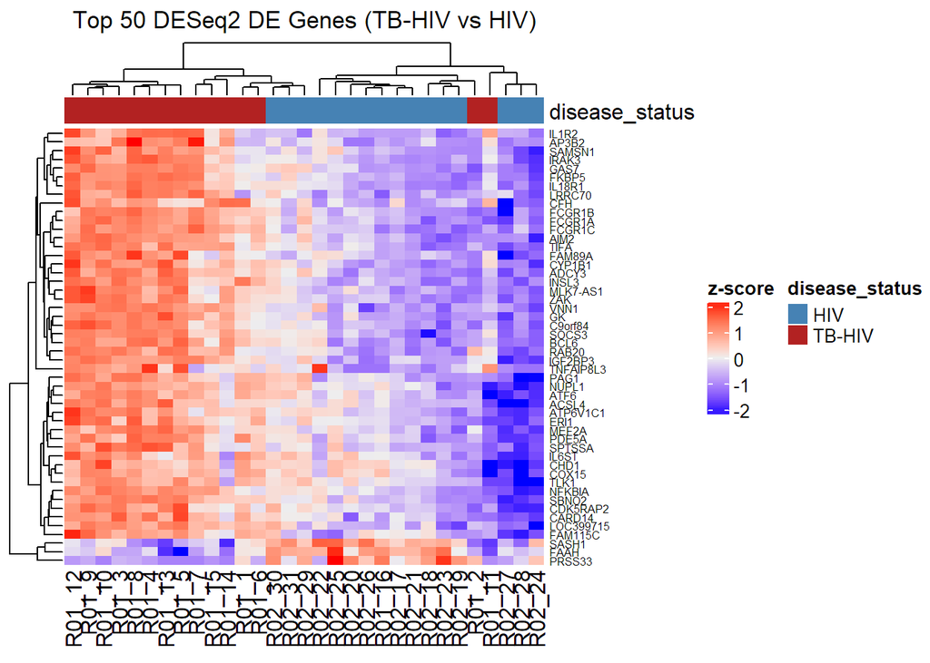

```r
library(ComplexHeatmap)
library(circlize)

# Top 50 genes from DESeq2 results
top50 <- rownames(res_ordered)[1:50]

# Pull their logCPM values
mat <- assay(se, "logCPM")[top50, ]

# Scale by row (z-score) so the heatmap shows relative expression patterns
mat_scaled <- t(scale(t(mat)))

# Annotation colorbar for disease status
ha <- HeatmapAnnotation(
  disease_status = se$disease_status,
  col = list(disease_status = c("TB-HIV" = "firebrick", "HIV" = "steelblue"))
)

Heatmap(
  mat_scaled,
  name = "z-score",
  top_annotation = ha,
  show_row_names = TRUE,
  show_column_names = TRUE,
  column_title = "Top 50 DESeq2 DE Genes (TB-HIV vs HIV)",
  row_names_gp = grid::gpar(fontsize = 6)
)
```

##### 10. Conduct a pathway analysis of the top 50 Limma genes using enrichR (through R or online). Use the “Reactome_Pathways_2024” database. What is the top scoring pathway?

```r
require("enrichR")  # if not already installed
library(enrichR)

# Confirm the database is available
dbs <- listEnrichrDbs()
"Reactome_Pathways_2024" %in% dbs$libraryName
```

```
## [1] TRUE
```

```r
# Top 50 limma genes
top50_limma <- rownames(res_limma)[1:50]

# Run enrichment
enriched <- enrichr(top50_limma, databases = "Reactome_Pathways_2024")
```

```
## Uploading data to Enrichr... Done.
##   Querying Reactome_Pathways_2024... Done.
## Parsing results... Done.
```

```r
# View top results
reactome_results <- enriched[["Reactome_Pathways_2024"]]
head(reactome_results[order(reactome_results$P.value), c("Term","P.value","Adjusted.P.value")], 50)
```

```
##                                                                                               Term
## 1                                                                        Smooth Muscle Contraction
## 2                                                                           Platelet Degranulation
## 3                                                     Response to Elevated Platelet Cytosolic Ca2+
## 4                                                                   Interleukin-1 Family Signaling
## 5                                                                        Signaling by Interleukins
## 6                                                                                ECM Proteoglycans
## 7                                                           Signaling by TGF-beta Receptor Complex
## 8                                                                               Endogenous Sterols
## 9                                                                            Syndecan Interactions
## 10                                                                         Interleukin-1 Signaling
## 11                                             Metabolic Disorders of Biological Oxidation Enzymes
## 12                                                        Molecules Associated With Elastic Fibres
## 13                                                  Platelet Activation, Signaling and Aggregation
## 14                                                                         Elastic Fibre Formation
```

[output cut: 87 more lines]

```r
# Top scoring pathway:
reactome_results$Term[which.min(reactome_results$P.value)]
```

```
## [1] "Smooth Muscle Contraction"
```

##### 11. Conduct a TBSignatureProfiler analysis on these data – including signature heatmaps, individual boxplots, and AUC boxplots. Interpret your findings. Upload one of your TBSignatureProfiler plots here.

```r
library(TBSignatureProfiler)

# Run profiling using ssGSEA on the logCPM assay
sigs_result <- runTBsigProfiler(
  input        = se,
  useAssay     = "logCPM",
  algorithm    = "ssGSEA",
  signatures   = TBsignatures,   # the full built-in signature library
  parallel.sz  = 1,
  combineSigAndAlgorithm = TRUE
)

# Check what signature score columns got added
colnames(colData(sigs_result))
```

```
##  [1] "sample_name"       "SampleID"          "disease_status"
##  [4] "Anderson_42"       "Anderson_OD_51"    "Berry_393"
##  [7] "Berry_OD_86"       "Blankley_380"      "Blankley_5"
## [10] "Bloom_OD_144"      "Bloom_RES_268"     "Bloom_RES_558"
## [13] "Chen_5"            "Chen_HIV_4"        "Darboe_RISK_11"
## [16] "Dawany_HIV_251"    "Duffy_23"          "Esmail_203"
## [19] "Esmail_82"         "Esmail_OD_893"     "Estevez_133"
## [22] "Estevez_259"       "Francisco_OD_2"    "Gjoen_10"
## [25] "Gjoen_7"           "Gliddon_2_OD_4"    "Gliddon_HIV_3"
## [28] "Gliddon_OD_3"      "Gliddon_OD_4"      "Gong_OD_4"
## [31] "Heycken_FAIL_22"   "Hoang_OD_13"       "Hoang_OD_20"
## [34] "Hoang_OD_3"        "Huang_OD_13"       "Jacobsen_3"
## [37] "Jenum_8"           "Kaforou_27"        "Kaforou_OD_44"
## [40] "Kaforou_OD_53"     "Kaul_3"            "Kulkarni_HIV_2"
## [43] "Kwan_186"          "LauxdaCosta_OD_3"  "Lee_4"
## [46] "Leong_24"          "Leong_RISK_29"     "Li_3"
## [49] "Long_RES_10"       "Maertzdorf_15"     "Maertzdorf_4"
## [52] "Maertzdorf_OD_100" "Natarajan_7"       "PennNich_RISK_6"
## [55] "Qian_OD_17"        "Rajan_HIV_5"       "Roe_3"
## [58] "Roe_OD_4"          "Sambarey_HIV_10"   "Singhania_OD_20"
## [61] "Sivakumaran_11"    "Sloot_HIV_2"       "Suliman_4"
## [64] "Suliman_RISK_2"    "Suliman_RISK_4"    "Sweeney_OD_3"
## [67] "Tabone_OD_11"      "Tabone_RES_25"     "Tabone_RES_27"
## [70] "Thompson_9"        "Thompson_FAIL_13"  "Thompson_RES_5"
## [73] "Tornheim_71"       "Tornheim_RES_25"   "Vargas_18"
## [76] "Vargas_42"         "Verhagen_10"       "Walter_51"
## [79] "Walter_PNA_119"    "Walter_PNA_47"     "Zak_RISK_16"
## [82] "Zhao_NANO_6"
```

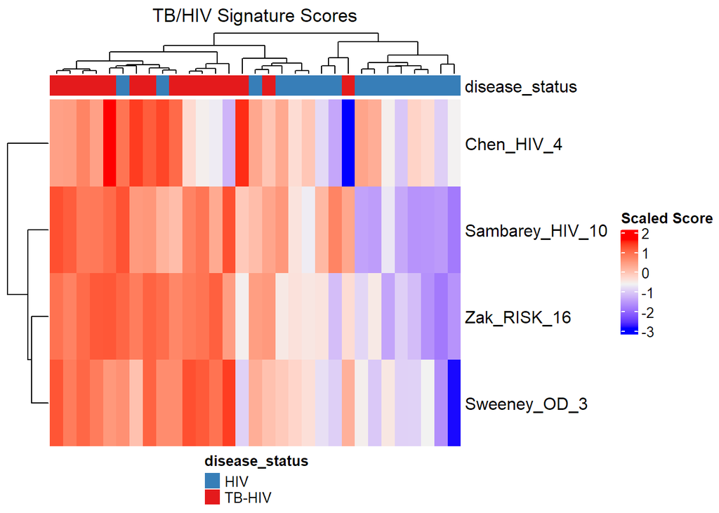

```r
sigs_to_plot <- c("Chen_HIV_4", "Sambarey_HIV_10", "Sweeney_OD_3", "Zak_RISK_16")

signatureHeatmap(
  sigs_result,
  signatureColNames = sigs_to_plot,
  annotationColNames = "disease_status",
  scale = TRUE,
  showColumnNames = FALSE,
  name = "TB/HIV Signature Scores"
)
```

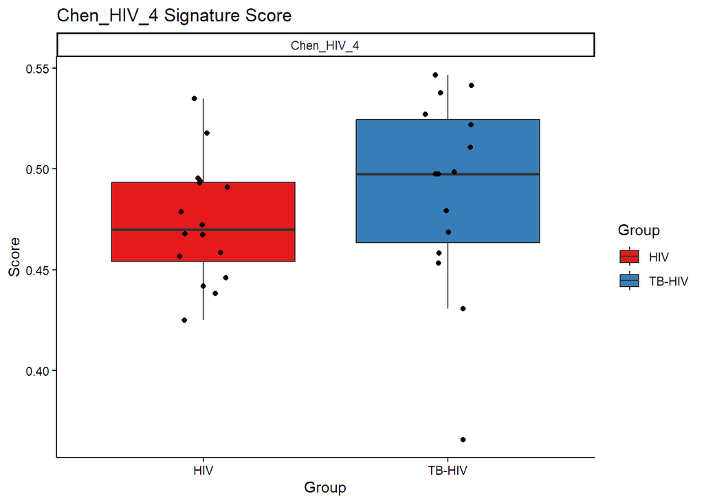

```r
signatureBoxplot(
  inputData = sigs_result,
  name = "Chen_HIV_4 Signature Score",
  signatureColNames = "Chen_HIV_4",
  annotationColName = "disease_status"
)
```

```r
auc_table <- tableAUC(
  SE_scored = sigs_result,
  annotationColName = "disease_status",
  signatureColNames = sigs_to_plot,
  num.boot = 100
)
```

```
##   |                                                                              |                                                                      |   0%
```

```
##   |                                                                              |==================                                                    |  25%
```

```
##   |                                                                              |===================================                                   |  50%
```

```
##   |                                                                              |====================================================                  |  75%
```

```
##   |                                                                              |======================================================================| 100%
```

```r
auc_table
```

| Signature | P.value | neg10xLog.P.value. | LowerAUC | AUC | UpperAUC |
| --- | --- | --- | --- | --- | --- |
| Sweeney_OD_3 | 0 | 101.6372 | 0.7831 | 0.9083 | 0.9933 |
| Zak_RISK_16 | 0 | 108.9873 | 0.746 | 0.8833 | 0.9814 |
| Sambarey_HIV_10 | 0.0001 | 90.9185 | 0.7303 | 0.8708 | 0.9909 |
| Chen_HIV_4 | 0.3038 | 11.9127 | 0.5181 | 0.675 | 0.8224 |